# Indicadores de pobreza com a PNAD Contínua.

Vitor Hugo Miro (UFC)

23/07/2021

## A PNAD Contínua

A Pesquisa Nacional por Amostra de Domicílios Contínua (PNADC) foi implantada em caráter definitivo a partir de janeiro de 2012, e a partir de 2016 passou a substituir a PNAD no levantamento das principais informações socioeconômicas no Brasil.

Sobre a PNDC: [Página da PNAD Contínua no IBGE](https://www.ibge.gov.br/estatisticas/sociais/rendimento-despesa-e-consumo/9171-pesquisa-nacional-por-amostra-de-domicilios-continua-mensal.html?=&t=o-que-e).

## R e R Studio

- Sobre o R https://www.r-project.org/
  - [Instalação](https://cran-r.c3sl.ufpr.br/)
- Sobre o RStudio https://www.rstudio.com/products/rstudio/
  - [Instalação](https://www.rstudio.com/products/rstudio/download/)
  - O **RStudio** é um ambiente de Desenvolvimento Integrado (IDE - integrated development environment) para uso do R.

## Preparar ambiente

Alguns comandos úteis antes de iniciar um projeto de análise de dados no R.

```r
# limpar "área de trabalho" do R (memória R)
#rm(list = ls())

# Definir um diretório de trabalho.
#setwd("C:/Users/vitor/Documents/LEP")

options(scipen = 999) # para evitar notação científica.
```

## Pacotes (Libraries)

Para a nossa análise vamos utilizar os seguintes pacotes:

- [PNADcIBGE](https://cran.r-project.org/web/packages/PNADcIBGE/index.html)
  - O pacote **PNADcIBGE** foi desenvolvido para facilitar o download, importação e análise dos dados amostrais da PNAD Contínua do IBGE.
- [survey](http://cran.fhcrc.org/web/packages/survey/index.html)
  - O pacote **survey** permite analisar dados sob amostragem complexa.
- [convey](https://cran.r-project.org/web/packages/convey/index.html)
  - O **convey** é um pacote livre, de código aberto, para uso em ambiente R que oferece funções para o cálculo de indicadores de pobreza, desigualdade e bem-estar.

## Carregar pacotes

```r
library(PNADcIBGE)

library(survey)
```

## Escolher variáveis

Ao invés de carregar todos os dados da PNADC, podemos definir um vetor de variáveis de interesse.

```r
# Definir variáveis utilizadas na análise
variaveis <- c('Ano', 'UF', 'Estrato', 'UPA', 'V1008', 'V1014', 'V1032',
               'V1022', 'V2001', 'V2005', 'V2007', 'V2009',
               'VD4001', 'VD4002', 'VD4016', 'VD4017',
               'VD4019', 'VD4020', 'VD4022', 'VD4048', 'VD5008')
```

## Pacote ‘PNADcIBGE’ e função ‘get_pnadc’

O Pacote PNADcIBGE foi desenvolvido para faciliar o download, importação e análise dos dados da PNADC. Ele permite baixar, rotular, deflacionar e criar objeto de desenho amostral (survey design) para os microdados da PNADC.

A função `get_pnadc` faz o trabalho de download, leitura, rotulação e criação do objeto do plano amostral da pesquisa. Esta função pode ser usada para microdados trimestrais e anuais. A função também incorpora argumentos para deflacionar valores monetários e salvar os arquivos da PNADC.

## get_pnadc

```r
# Carrega dados da PNADC
pnadc <- get_pnadc(year = 2019,
                   vars = variaveis,
                   interview = 1,
                   design = TRUE,
                   labels = TRUE,
                   deflator = TRUE,
                   defyear = 2019)
```

```
tentando a URL 'https://ftp.ibge.gov.br/Trabalho_e_Rendimento/Pesquisa_Nacional_por_Amostra_de_Domicilios_continua/Anual/Microdados/Visita/Visita_1/Dados/PNADC_2019_visita1_20200826.zip'

tentando a URL 'https://ftp.ibge.gov.br/Trabalho_e_Rendimento/Pesquisa_Nacional_por_Amostra_de_Domicilios_continua/Anual/Microdados/Visita/Visita_1/Documentacao/input_PNADC_2019_visita1_20200826.txt'

tentando a URL 'https://ftp.ibge.gov.br/Trabalho_e_Rendimento/Pesquisa_Nacional_por_Amostra_de_Domicilios_continua/Anual/Microdados/Visita/Visita_1/Documentacao/dicionario_PNADC_microdados_2019_visita1_20210617.xls'

tentando a URL 'https://ftp.ibge.gov.br/Trabalho_e_Rendimento/Pesquisa_Nacional_por_Amostra_de_Domicilios_continua/Anual/Microdados/Visita/Documentacao_Geral/deflator_PNADC_2019.xls'
```

## Detalhes da base

A função `str` permite verificar a estrutura de qualquer objeto no R.

```r
str(pnadc)
```

```
List of 10
 $ cluster   :'data.frame': 443790 obs. of  1 variable:
  ..$ UPA: Factor w/ 12087 levels "1110011.110000016",..: 1 1 1 1 1 1 1 1 1 1 ...
  ..- attr(*, "terms")=Classes 'terms', 'formula'  language ~UPA
  .. .. ..- attr(*, "variables")= language list(UPA)
  .. .. ..- attr(*, "factors")= int [1, 1] 1
  .. .. .. ..- attr(*, "dimnames")=List of 2
  .. .. .. .. ..$ : chr "UPA"
  .. .. .. .. ..$ : chr "UPA"
  .. .. ..- attr(*, "term.labels")= chr "UPA"
  .. .. ..- attr(*, "order")= int 1
  .. .. ..- attr(*, "intercept")= int 1
  .. .. ..- attr(*, "response")= int 0
  .. .. ..- attr(*, ".Environment")=<environment: 0x000001f625170cc0>
  .. .. ..- attr(*, "predvars")= language list(UPA)
  .. .. ..- attr(*, "dataClasses")= Named chr "character"
  .. .. .. ..- attr(*, "names")= chr "UPA"
 $ strata    :'data.frame': 443790 obs. of  1 variable:
  ..$ Estrato: chr [1:443790] "1110011" "1110011" "1110011" "1110011" ...
  ..- attr(*, "terms")=Classes 'terms', 'formula'  language ~Estrato
  .. .. ..- attr(*, "variables")= language list(Estrato)
  .. .. ..- attr(*, "factors")= int [1, 1] 1
  .. .. .. ..- attr(*, "dimnames")=List of 2
  .. .. .. .. ..$ : chr "Estrato"
  .. .. .. .. ..$ : chr "Estrato"
  .. .. ..- attr(*, "term.labels")= chr "Estrato"
  .. .. ..- attr(*, "order")= int 1
  .. .. ..- attr(*, "intercept")= int 1
  .. .. ..- attr(*, "response")= int 0
  .. .. ..- attr(*, ".Environment")=<environment: 0x000001f625170cc0>
  .. .. ..- attr(*, "predvars")= language list(Estrato)
  .. .. ..- attr(*, "dataClasses")= Named chr "character"
  .. .. .. ..- attr(*, "names")= chr "Estrato"
 $ has.strata: logi TRUE
 $ prob      : Named num [1:443790] 0.00637 0.00637 0.00637 0.00637 0.00637 ...
  ..- attr(*, "names")= chr [1:443790] "1" "2" "3" "4" ...
 $ allprob   :'data.frame': 443790 obs. of  1 variable:
  ..$ V1031: num [1:443790] 0.00934 0.00934 0.00934 0.00934 0.00934 ...
 $ call      : language survey::postStratify(design = data_prior, strata = ~posest, population = popc.types)
 $ variables :'data.frame': 443790 obs. of  31 variables:
```

[output cut: 28 more lines]

```
  ..$ CO2      : num [1:443790] 1.01 1.01 1.01 1.01 1.01 ...
  ..$ CO2e     : num [1:443790] 1.02 1.02 1.02 1.02 1.02 ...
  ..$ CO3      : num [1:443790] 1 1 1 1 1 1 1 1 1 1 ...
 $ fpc       :List of 2
  ..$ popsize : NULL
  ..$ sampsize: int [1:443790, 1] 42 42 42 42 42 42 42 42 42 42 ...
  ..- attr(*, "class")= chr "survey_fpc"
 $ pps       : logi FALSE
 $ postStrata:List of 1
  ..$ : int [1:443790] 1 1 1 1 1 1 1 1 1 1 ...
  .. ..- attr(*, "oldweights")= Named num [1:443790] 107 107 107 107 107 ...
  .. .. ..- attr(*, "names")= chr [1:443790] "1" "2" "3" "4" ...
  .. ..- attr(*, "weights")= Named num [1:443790] 157 157 157 157 157 ...
  .. .. ..- attr(*, "names")= chr [1:443790] "1" "2" "3" "4" ...
 - attr(*, "class")= chr [1:2] "survey.design2" "survey.design"
```

## Detalhes da base

A função `class` permite checar o tipo de objeto no R.

```r
class(pnadc)
```

```
[1] "survey.design2" "survey.design"
```

## Estatísticas básicas com o ‘survey’

Vamos ver aplicações de funções estatísticas do pacote `survey`.

- Totais: `svytotal`
- Médias (e proporções): `svymean`
- Razões:`svyratio`

Também podem ser utilizadas funções para estimação de:

- variância (`svyvar`)
- intervalos de confiança (`confint`)
- quantis (`svyquantile`)
- modelos de regressão (`svyglm`)
- [Entre outros](http://faculty.washington.edu/tlumley/old-survey/index.html).

## Estatísticas básicas com o ‘survey’

Totais (`svytotal`)

```r
# Totais - svytotal
popuf <- svytotal(~UF, pnadc, na.rm = TRUE)
popuf
```

```
                         total SE
UFRondônia             1766689  0
UFAcre                  865422  0
UFAmazonas             3983005  0
UFRoraima               539741  0
UFPará                 8561098  0
UFAmapá                 837575  0
UFTocantins            1559657  0
UFMaranhão             7040610  0
UFPiauí                3272447  0
UFCeará                9129378  0
UFRio Grande do Norte  3506853  0
UFParaíba              3996784  0
UFPernambuco           9499409  0
UFAlagoas              3330079  0
UFSergipe              2298549  0
UFBahia               14853512  0
UFMinas Gerais        21158152  0
UFEspírito Santo       4014926  0
UFRio de Janeiro      17264410  0
UFSão Paulo           45912673  0
UFParaná              11420565  0
UFSanta Catarina       7153029  0
UFRio Grande do Sul   11358646  0
UFMato Grosso do Sul   2709334  0
UFMato Grosso          3430698  0
UFGoiás                7020504  0
UFDistrito Federal     3012718  0
```

## Estatísticas básicas com o ‘survey’

Médias (`svymean`)

```r
rdpc <- svymean(~VD5008, pnadc, na.rm = TRUE)
rdpc
```

```
         mean     SE
VD5008 1404.6 18.495
```

## Estatísticas básicas com o ‘survey’

Proporções - variáveis categóricas (`svymean`)

```r
psexo <- svymean(~V2007, pnadc, na.rm = TRUE)
psexo
```

```
               mean     SE
V2007Homem  0.48246 0.0008
V2007Mulher 0.51754 0.0008
```

## Estatísticas básicas com o ‘survey’

Razões entre duas variáveis (`svyratio`)

```r
txdesocup <- svyratio(~VD4002 == "Pessoas desocupadas",
                      ~VD4001 == "Pessoas na força de trabalho",
                      pnadc,
                      na.rm = TRUE)
txdesocup
```

```
Ratio estimator: svyratio.survey.design2(~VD4002 == "Pessoas desocupadas",
    ~VD4001 == "Pessoas na força de trabalho", pnadc,
    na.rm = TRUE)
Ratios=
                                VD4001 == "Pessoas na força de trabalho"
VD4002 == "Pessoas desocupadas"                                0.1165897
SEs=
                                VD4001 == "Pessoas na força de trabalho"
VD4002 == "Pessoas desocupadas"                              0.001237404
```

## Estimação condicionada (subset)

```r
rdpc_ce <- svymean(~VD5008, subset(pnadc, UF == "Ceará"), na.rm = TRUE)
rdpc_ce
```

```
         mean     SE
VD5008 938.14 47.789
```

## Estimação condicionada (subset)

```r
rdpc_ce_rural <- svymean(~VD5008,
                         subset(pnadc, UF == "Ceará" & V1022 =="Rural"),
                         na.rm = TRUE)
rdpc_ce_rural
```

```
         mean     SE
VD5008 429.17 10.509
```

## O Pacote Convey

O Pacote `convey` permite estimar diversos indicadores de pobreza e desigualdade de renda para dados provenientes de pesquisas com planos amostrais complexos.

Este pacote segue uma sintaxe bem próxima à sintaxe do `survey`, sendo possível utilizar funções do `survey` em objetos do `convey`.

Para a utilização do pacote `convey` é necessário utilizar a função `convey_prep`, que transforma o objeto do plano amostral do `survey` no objeto que o `convey`.

- [Mais sobre o uso do convey](https://guilhermejacob.github.io/context/).

## Carregando o pacote Convey e preparando os dados

```r
library(convey)

pnadc <- convey_prep(pnadc)
class(pnadc)
```

```
[1] "convey.design"  "survey.design2" "survey.design"
```

## Indicadores de pobreza com o ‘convey’

O pacote conveu fornece funções para o cálculo da família de indicadores de pobreza proposta por Foster, Greer e Thorbecke (1984).

$$FGT(\alpha)=\frac{1}{N} \sum_{i=1}^N \left(\frac{z - y_i}{z}\ \right)^{\alpha} \mathbb{I}(y_i<z) \quad , \alpha \geq0$$
Em que:

- $y_i$ é uma medida de bem-estar (renda ou consumo);
- $z$ é a linha de pobreza;
- $\mathbb{I}(y_i<z)$ é uma função indicadora;
- $\alpha$ é uma constante não-negativa.

Seguindo a estrutura de indicadores FGT temos:

- Se $\alpha = 0$: FGT(0) é a proporção de pobres (poverty headcount ratio);
- Se $\alpha = 1$: FGT(1) é uma medida de hiato da pobreza ou intensidade da pobreza (poverty gap);
- Se $\alpha = 2$: FGT(2) é uma medida de hiato quadrático da pobreza ou severidade da pobreza;

```r
fgt0 <- svyfgt(~VD5008, pnadc, g=0, abs_thresh = 436, na.rm = TRUE)
fgt0
```

```
          fgt0     SE
VD5008 0.24818 0.0022
```

```r
fgt1 <- svyfgt(~VD5008, pnadc, g=1, abs_thresh = 436, na.rm = TRUE)
fgt1
```

```
         fgt1     SE
VD5008 0.1108 0.0011
```

```r
fgt2 <- svyfgt(~VD5008, pnadc, g=2, abs_thresh = 436, na.rm = TRUE)
fgt2
```

```
           fgt2     SE
VD5008 0.069489 0.0008
```

## Indicadores de desigualdade com o ‘convey’

Com o `convey` também podemos calcular o Índice de Gini.

A *curva de Lorenz* é um instrumento clássico de análise de distribuição de renda.

Considerando a distribuição da renda $y$, representada por $f(y)$, a curva de Lorenz associa uma parcela cumulativa da população à parcela da renda total:

$$L(p) = \frac{\int_{-\infty}^{Q_p}yf(y)dy}{\int_{-\infty}^{+\infty}yf(y)dy}$$
, onde $Q_p$ é o quantil $p$ da população.

```
$quantiles
       0        0.05         0.1       0.15        0.2       0.25        0.3       0.35      0.4      0.45
VD5008 0 0.001878506 0.007937296 0.01723493 0.02897404 0.04321308 0.06038047 0.07961121 0.102007 0.1272168
            0.5    0.55       0.6      0.65       0.7     0.75       0.8      0.85       0.9      0.95 1
VD5008 0.155752 0.18862 0.2241789 0.2628309 0.3067873 0.357189 0.4152626 0.4844771 0.5712464 0.6937334 1

$CIs
, , VD5008

       0        0.05         0.1       0.15        0.2       0.25        0.3       0.35       0.4      0.45
(lower 0 0.001864937 0.007885241 0.01712504 0.02879080 0.04294016 0.05999979 0.07910968 0.1013645 0.1264157
upper) 0 0.001892075 0.007989352 0.01734482 0.02915728 0.04348600 0.06076115 0.08011274 0.1026495 0.1280180
             0.5      0.55       0.6      0.65       0.7      0.75       0.8      0.85       0.9      0.95 1
(lower 0.1547707 0.1874321 0.2227674 0.2611765 0.3048527 0.3549385 0.4126481 0.4814286 0.5676531 0.6893714 1
upper) 0.1567333 0.1898079 0.2255903 0.2644854 0.3087219 0.3594395 0.4178771 0.4875257 0.5748397 0.6980954 1
```

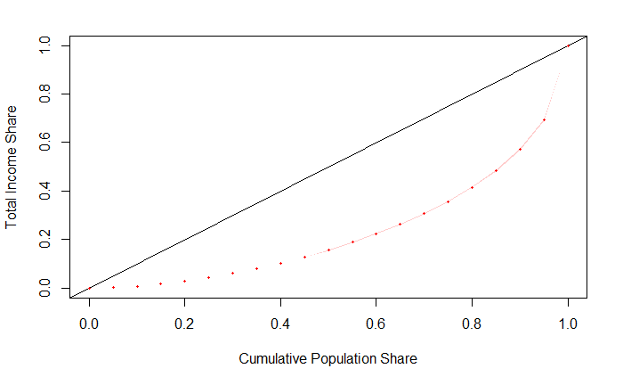

```r
svylorenz(~VD5008, pnadc, quantiles = seq( 0, 1, .05 ), na.rm = TRUE )
```

O Índice de Gini é uma tentativa de expressar a desigualdade apresentada na curva de Lorenz como um único número. Em essência, é o dobro da área entre a curva de igualdade e a curva de Lorenz real.

$$\begin{aligned}
G &= 2 \bigg( \int_{0}^{1} pdp - \int_{0}^{1} L(p)dp \bigg) \\
G &= 1 - 2 \int_{0}^{1} L(p)dp
\end{aligned}$$
Onde $G = 0$ representa igualdade perfeita e $G = 1$ desigualdade perfeita.

```r
gini <- svygini(~VD5008, pnadc, na.rm = TRUE)

gini_ce <- svygini(~VD5008, subset(pnadc, UF == "Ceará"), na.rm = TRUE)

gini
```

```
          gini     SE
VD5008 0.54286 0.0042
```

```r
gini_ce
```

```
          gini     SE
VD5008 0.56151 0.0167
```